# Biostatistical Methods I - HW1

JingYao Geng

9/24/2020

## Problem 1

#### 1.1.a: Descriptive Statistics

- The **Antibodies** data set contains a total of **1491** observations and **5** variables.
  - **1224** missing values are founded in variable called **Antibody_IgM**.
  - **34** observations of variable **Smell** are categorized as “Unanswered/others”.
  - The rest of variables: **Subject**, **AgeCategory**, and **Gender** contain no missing values.
- The following table shows the **descriptive statistics** for all the variable of interest.
  - **Numeric variable: Subject, Antibody_IgM**
  - **Categorical variable: AgeCategory, Gender, Smell**

```
##
## Table: Descriptive Statistics: Antibodies Data
##
## |                     |       Overall (N=1491)       |
## |:--------------------|:----------------------------:|
## |Subject              |                              |
## |-  Mean (SD)         |      1413.751 (881.073)      |
## |-  Median (Q1, Q3)   | 1373.000 (632.500, 2190.500) |
## |-  Min - Max         |       1.000 - 2917.000       |
## |-  Missing           |              0               |
## |Antibody(IgM)        |                              |
## |-  Mean (SD)         |        0.124 (0.110)         |
## |-  Median (Q1, Q3)   |     0.091 (0.069, 0.129)     |
## |-  Min - Max         |        0.048 - 1.048         |
## |-  Missing           |             1224             |
## |Age                  |                              |
## |-  18-30             |         318 (21.3%)          |
## |-  31-50             |         810 (54.3%)          |
## |-  51+               |         363 (24.3%)          |
## |-  Missing           |              0               |
## |Smell                |                              |
## |-  Altered           |         1047 (70.2%)         |
## |-  Normal            |         410 (27.5%)          |
## |-  Unanswered/Others |          34 (2.3%)           |
## |-  Missing           |              0               |
## |Gender               |                              |
## |-  Female            |         981 (65.8%)          |
## |-  Male              |         510 (34.2%)          |
## |-  Missing           |              0               |
```

#### 1.1.b: Histogram for the Ig_M values

The histogram of Antibody_IgM shows a right skewed distribution, where the mean of the Antibodies_IgM level tends to be ‘pulled’ toward the right tail of the distribution.

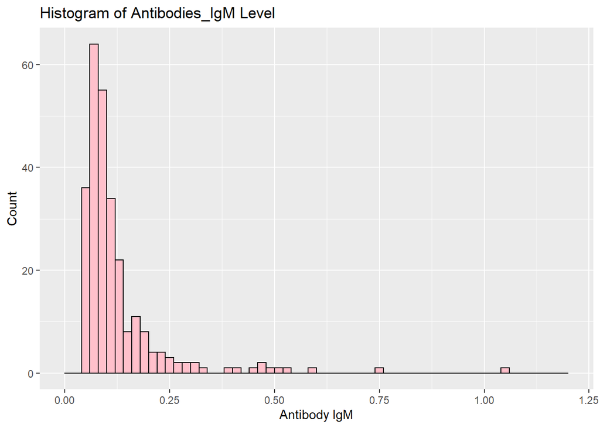

#### 1.2.a: Descriptive Statistics Stratified by Smell

- There are more observations in the Altered collection of Smell, regardless the variable Age, Gender, and Antibody_IgM.
- The normal group of Semll is more evenly distributed in gender than the altered group.
- Age range 31-50 contributes more than 50% of the observations in both normal and altered groups.

```
##
## Table: Descriptive Statistics Stratified by Smell
##
## |                   |   Altered (N=519)    |    Normal (N=202)    |
## |:------------------|:--------------------:|:--------------------:|
## |Age                |                      |                      |
## |-  18-30           |     117 (22.5%)      |      33 (16.3%)      |
## |-  31-50           |     278 (53.6%)      |     106 (52.5%)      |
## |-  51+             |     124 (23.9%)      |      63 (31.2%)      |
## |-  Missing         |          0           |          0           |
## |Gender             |                      |                      |
## |-  Female          |     369 (71.1%)      |     119 (58.9%)      |
## |-  Male            |     150 (28.9%)      |      83 (41.1%)      |
## |-  Missing         |          0           |          0           |
## |Antibody(IgM)      |                      |                      |
## |-  Mean (SD)       |    0.131 (0.128)     |    0.111 (0.078)     |
## |-  Median (Q1, Q3) | 0.098 (0.067, 0.139) | 0.084 (0.064, 0.121) |
## |-  Min - Max       |    0.048 - 1.048     |    0.048 - 0.465     |
## |-  Missing         |         427          |         166          |
```

#### 1.2.b: Group Boxplots and Side-by-side Histogram

**Boxplots**:

[figure not shown]

[output not shown]

**Histogram**:

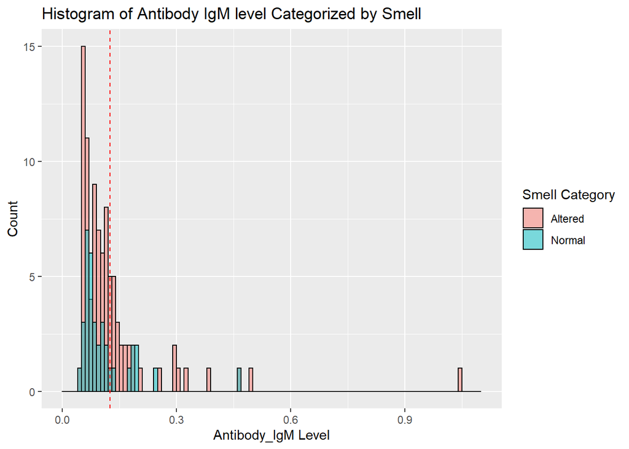

- Both Altered and Normal groups display a right skewed distribution overall. With the increase of Antibody_IgM level, the number of observations decrease for both groups.
- There are more observations in the altered group.

## Question 2

This study’s primary goal is to investigate how pregnant women’s exposure to marijuana is associated with adverse outcomes among children, such as psychotic-like behaviors.

This study was based on a population size of 11489 children and collected from the Adolescent Brain Cognitive Development study. According to the corresponding 11489 mothers’ statements, the 11489 children were divided into two groups: exposed to or not to cannabis while in utero, and investigated by cross-sectional analysis.

The potential bias or the limitation is whether the grouping was reliable and creditable since it depended on the mothers’ recalls. If some of the mothers recalled their memory wrong, the story might be different. Moreover, since we cannot design a controlled experiment easily and practically, we cannot tell whether other factors cause the offspring’s adverse outcomes or not.

Lastly, I think the study results help account how the use of marijuana during pregnancy is harmful to the offspring. Besides this study, data from the US Centers for Disease Control and Prevention has also shown that the use of marijuana during pregnancy can develop harmful issues in children, such as low birth weight, impulsivity, hyperactivity, and so on. Therefore, I would strongly agree with this article’s results: marijuana use during pregnancy should be discouraged.

Recommendations: The legalization of marijuana has been the subject constant debated among people. Marijuana indeed has some health benefits in relieving chronic pain, improving lung capacity, and so on. However, it cannot guarantee that all use of marijuana among people is proper and legal. I would agree and only agree with some medical uses. Besides that, marijuana is the thing that all countries should get control of.

In this case, I would discourage pregnant women from using cannabis/marihuana/weed.

References: LaMotte, Sandee. “Using Weed during Pregnancy Linked to Psychotic-like Behaviors in Children, Study Finds.” CNN, Cable News Network, 23 Sept. 2020, www.cnn.com/2020/09/23/health/weed-pregnancy-childhood-psychosis-trnd-wellness/index.html.